# Importing the Libraries

```python
# Libraries for Data Analysis
import pandas as pd
import seaborn as sns
import numpy as np
from scipy.stats import iqr
import matplotlib.pyplot as plt
import matplotlib.image as img
import pandas as pd

# Libraries for Regression Model
from sklearn.linear_model import LinearRegression
from sklearn.model_selection import train_test_split
from sklearn.metrics import confusion_matrix
from sklearn import preprocessing # for converting categorical variables into numerics, didn't use this library
from sklearn.metrics import accuracy_score
from sklearn.metrics import r2_score
```

# Importing Airbnb Data

```python
url = "http://oguzayy.github.io/python/AB_NYC_2019.csv"
airbnb = pd.read_csv(url)

airbnb.head(5)
```

|  | id | name | host_id | host_name | neighbourhood_group | neighbourhood | latitude | longitude | room_type | price | minimum_nights | number_of_reviews | last_review | reviews_per_month | calculated_host_listings_count | availability_365 |
| --- | --- | --- | --- | --- | --- | --- | --- | --- | --- | --- | --- | --- | --- | --- | --- | --- |
| 0 | 2539 | Clean & quiet apt home by the park | 2787 | John | Brooklyn | Kensington | 40.64749 | -73.97237 | Private room | 149 | 1 | 9 | 2018-10-19 | 0.21 | 6 | 365 |
| 1 | 2595 | Skylit Midtown Castle | 2845 | Jennifer | Manhattan | Midtown | 40.75362 | -73.98377 | Entire home/apt | 225 | 1 | 45 | 2019-05-21 | 0.38 | 2 | 355 |
| 2 | 3647 | THE VILLAGE OF HARLEM....NEW YORK ! | 4632 | Elisabeth | Manhattan | Harlem | 40.80902 | -73.94190 | Private room | 150 | 3 | 0 | NaN | NaN | 1 | 365 |
| 3 | 3831 | Cozy Entire Floor of Brownstone | 4869 | LisaRoxanne | Brooklyn | Clinton Hill | 40.68514 | -73.95976 | Entire home/apt | 89 | 1 | 270 | 2019-07-05 | 4.64 | 1 | 194 |
| 4 | 5022 | Entire Apt: Spacious Studio/Loft by central park | 7192 | Laura | Manhattan | East Harlem | 40.79851 | -73.94399 | Entire home/apt | 80 | 10 | 9 | 2018-11-19 | 0.10 | 1 | 0 |

Let's have a look at the variables in data and their data types.

```python
airbnb.info()
```

```
<class 'pandas.core.frame.DataFrame'>
RangeIndex: 48895 entries, 0 to 48894
Data columns (total 16 columns):
id                                48895 non-null int64
name                              48879 non-null object
host_id                           48895 non-null int64
host_name                         48874 non-null object
neighbourhood_group               48895 non-null object
neighbourhood                     48895 non-null object
latitude                          48895 non-null float64
longitude                         48895 non-null float64
room_type                         48895 non-null object
price                             48895 non-null int64
minimum_nights                    48895 non-null int64
number_of_reviews                 48895 non-null int64
last_review                       38843 non-null object
reviews_per_month                 38843 non-null float64
calculated_host_listings_count    48895 non-null int64
availability_365                  48895 non-null int64
dtypes: float64(3), int64(7), object(6)
memory usage: 6.0+ MB
```

There are 48,895 data in total. The variables are shown above. We will not use all of the variables for this analysis.

# Data Cleaning

## Checking for NULL Variables

The first step is to find if there are any NULL variables in data. Let's have a look at how many NULL values in each variables have.

```python
airbnb.isnull().sum()
```

```
id                                    0
name                                 16
host_id                               0
host_name                            21
neighbourhood_group                   0
neighbourhood                         0
latitude                              0
longitude                             0
room_type                             0
price                                 0
minimum_nights                        0
number_of_reviews                     0
last_review                       10052
reviews_per_month                 10052
calculated_host_listings_count        0
availability_365                      0
dtype: int64
```

The variable reviews_per_month is crucial for us, because we will use it in further analysis. So we need to clean the null variables. These are the null values of reviews_per_month. The null values in the last_review and reviews_per_month columns all occur for data where no reviews were given in the first place. Let's now check the null values for reviews_per_month.

```python
airbnb[airbnb.reviews_per_month.isnull()==True].head()
```

|  | id | name | host_id | host_name | neighbourhood_group | neighbourhood | latitude | longitude | room_type | price | minimum_nights | number_of_reviews | last_review | reviews_per_month | calculated_host_listings_count | availability_365 |
| --- | --- | --- | --- | --- | --- | --- | --- | --- | --- | --- | --- | --- | --- | --- | --- | --- |
| 2 | 3647 | THE VILLAGE OF HARLEM....NEW YORK ! | 4632 | Elisabeth | Manhattan | Harlem | 40.80902 | -73.94190 | Private room | 150 | 3 | 0 | NaN | NaN | 1 | 365 |
| 19 | 7750 | Huge 2 BR Upper East Cental Park | 17985 | Sing | Manhattan | East Harlem | 40.79685 | -73.94872 | Entire home/apt | 190 | 7 | 0 | NaN | NaN | 2 | 249 |
| 26 | 8700 | Magnifique Suite au N de Manhattan - vue Cloitres | 26394 | Claude & Sophie | Manhattan | Inwood | 40.86754 | -73.92639 | Private room | 80 | 4 | 0 | NaN | NaN | 1 | 0 |
| 36 | 11452 | Clean and Quiet in Brooklyn | 7355 | Vt | Brooklyn | Bedford-Stuyvesant | 40.68876 | -73.94312 | Private room | 35 | 60 | 0 | NaN | NaN | 1 | 365 |
| 38 | 11943 | Country space in the city | 45445 | Harriet | Brooklyn | Flatbush | 40.63702 | -73.96327 | Private room | 150 | 1 | 0 | NaN | NaN | 1 | 365 |

As the table above shows, there are 10,052 rows that has no reviews at all. So lets exclude them from our data.

## Cleaning the NULL Variables

```python
airbnb.dropna(subset=['reviews_per_month'], inplace=True)
airbnb.shape
```

```
(38843, 16)
```

After removing the null variables, we end up with 38,843 lines from our data.

```python
airbnb.head(5)
```

|  | id | name | host_id | host_name | neighbourhood_group | neighbourhood | latitude | longitude | room_type | price | minimum_nights | number_of_reviews | last_review | reviews_per_month | calculated_host_listings_count | availability_365 |
| --- | --- | --- | --- | --- | --- | --- | --- | --- | --- | --- | --- | --- | --- | --- | --- | --- |
| 0 | 2539 | Clean & quiet apt home by the park | 2787 | John | Brooklyn | Kensington | 40.64749 | -73.97237 | Private room | 149 | 1 | 9 | 2018-10-19 | 0.21 | 6 | 365 |
| 1 | 2595 | Skylit Midtown Castle | 2845 | Jennifer | Manhattan | Midtown | 40.75362 | -73.98377 | Entire home/apt | 225 | 1 | 45 | 2019-05-21 | 0.38 | 2 | 355 |
| 3 | 3831 | Cozy Entire Floor of Brownstone | 4869 | LisaRoxanne | Brooklyn | Clinton Hill | 40.68514 | -73.95976 | Entire home/apt | 89 | 1 | 270 | 2019-07-05 | 4.64 | 1 | 194 |
| 4 | 5022 | Entire Apt: Spacious Studio/Loft by central park | 7192 | Laura | Manhattan | East Harlem | 40.79851 | -73.94399 | Entire home/apt | 80 | 10 | 9 | 2018-11-19 | 0.10 | 1 | 0 |
| 5 | 5099 | Large Cozy 1 BR Apartment In Midtown East | 7322 | Chris | Manhattan | Murray Hill | 40.74767 | -73.97500 | Entire home/apt | 200 | 3 | 74 | 2019-06-22 | 0.59 | 1 | 129 |

Let's have a look at the data for null variables after cleaning. One alternative way is to replace these null variables with the averages. We could find the average review numbers for each individual neighbourhood groups and give the corresponding value to the null variables. In this analysis, we got rid of the data since 38 k variables are enough.

```python
airbnb.isnull().sum()
```

```
id                                 0
name                               6
host_id                            0
host_name                         16
neighbourhood_group                0
neighbourhood                      0
latitude                           0
longitude                          0
room_type                          0
price                              0
minimum_nights                     0
number_of_reviews                  0
last_review                        0
reviews_per_month                  0
calculated_host_listings_count     0
availability_365                   0
dtype: int64
```

Only name and host_name variables have NULL value. They are not essential for our analysis so we will keep them in order not to decrease our sample.

# Statistical Data Exploratory

Let's have a look at some statistical features for the numeric variables.

```python
airbnb.describe()
```

|  | id | host_id | latitude | longitude | price | minimum_nights | number_of_reviews | reviews_per_month | calculated_host_listings_count | availability_365 |
| --- | --- | --- | --- | --- | --- | --- | --- | --- | --- | --- |
| count | 3.884300e+04 | 3.884300e+04 | 38843.000000 | 38843.000000 | 38843.000000 | 38843.000000 | 38843.000000 | 38843.000000 | 38843.000000 | 38843.000000 |
| mean | 1.809646e+07 | 6.423915e+07 | 40.728134 | -73.951148 | 142.317947 | 5.868059 | 29.297557 | 1.373221 | 5.164457 | 114.882888 |
| std | 1.069370e+07 | 7.588847e+07 | 0.054990 | 0.046695 | 196.945624 | 17.384784 | 48.186374 | 1.680442 | 26.295665 | 129.543636 |
| min | 2.539000e+03 | 2.438000e+03 | 40.506410 | -74.244420 | 0.000000 | 1.000000 | 1.000000 | 0.010000 | 1.000000 | 0.000000 |
| 25% | 8.720027e+06 | 7.033824e+06 | 40.688640 | -73.982470 | 69.000000 | 1.000000 | 3.000000 | 0.190000 | 1.000000 | 0.000000 |
| 50% | 1.887146e+07 | 2.837193e+07 | 40.721710 | -73.954800 | 101.000000 | 2.000000 | 9.000000 | 0.720000 | 1.000000 | 55.000000 |
| 75% | 2.755482e+07 | 1.018465e+08 | 40.762990 | -73.935020 | 170.000000 | 4.000000 | 33.000000 | 2.020000 | 2.000000 | 229.000000 |
| max | 3.645581e+07 | 2.738417e+08 | 40.913060 | -73.712990 | 10000.000000 | 1250.000000 | 629.000000 | 58.500000 | 327.000000 | 365.000000 |

# Data Analysis

## Price Analysis

As it can be seen from Statistical Data Exploratory, there are some outliers with the price variable. It has a min of 0 and max of 10,000. So let's get rid of the outliers. So let's get rid of these outliers.

In order to do this, I grouped the data with respect to their neighrbourhood groups and found the lower and upper limits.

Lower limit is the first quartile - 1,5 *(third quartile - first quartile) Upper limit is the third quartile + 1,5* (third quartile - first quartile)

```python
brooklyn = airbnb[airbnb['neighbourhood_group'] == 'Brooklyn']
manhattan = airbnb[airbnb['neighbourhood_group'] == 'Manhattan']
queens = airbnb[airbnb['neighbourhood_group'] == 'Queens']
staten = airbnb[airbnb['neighbourhood_group'] == 'Staten Island']
bronx = airbnb[airbnb['neighbourhood_group'] == 'Bronx']

price_b = brooklyn[(brooklyn['price'] > np.quantile(brooklyn['price'], 0.25) - (1.5 * iqr(brooklyn['price']))) & (brooklyn['price'] < np.quantile(brooklyn['price'], 0.75) + (1.5 * iqr(brooklyn['price'])))]
price_m = manhattan[(manhattan['price'] > np.quantile(manhattan['price'], 0.25) - (1.5 * iqr(manhattan['price']))) & (manhattan['price'] < np.quantile(manhattan['price'], 0.75) + (1.5 * iqr(manhattan['price'])))]
price_q = queens[(queens['price'] > np.quantile(queens['price'], 0.25) - (1.5 * iqr(queens['price']))) & (queens['price'] < np.quantile(queens['price'], 0.75) + (1.5 * iqr(queens['price'])))]
price_s = staten[(staten['price'] > np.quantile(staten['price'], 0.25) - (1.5 * iqr(staten['price']))) & (staten['price'] < np.quantile(staten['price'], 0.75) + (1.5 * iqr(staten['price'])))]
price_br = bronx[(bronx['price'] > np.quantile(bronx['price'], 0.25) - (1.5 * iqr(bronx['price']))) & (bronx['price'] < np.quantile(bronx['price'], 0.75) + (1.5 * iqr(bronx['price'])))]

price = pd.concat([price_b, price_m, price_q, price_s, price_br], axis = 0)
```

### Room Prices for each Neighbourhoods

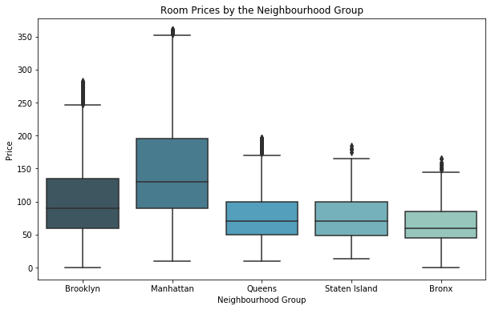

```python
plt.figure(figsize=(10,6))
sns.boxplot(x="neighbourhood_group", y="price", data=price, palette='GnBu_d')
plt.title("Room Prices by the Neighbourhood Group")
plt.xlabel('Neighbourhood Group')
plt.ylabel("Price")
plt.show()
```

We can see that the average prices in Manhattan is more than Brooklyn. And the prices in Brooklyn is more than Queens, Staten Island or Bronx. However there is no any superiority between Queens, Staten Island and Bronx.

### Number of Posts for each Room Type in Neighbour

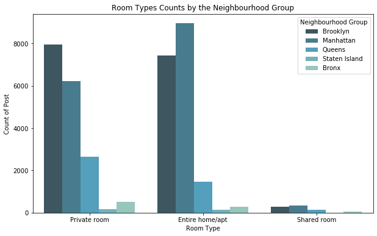

```python
plt.figure(figsize=(10,6))
sns.countplot(x = 'room_type',hue = "neighbourhood_group",data = price, palette='GnBu_d')
plt.title("Room Types Counts by the Neighbourhood Group")
plt.xlabel('Room Type')
plt.ylabel("Count of Post")
plt.legend(title="Neighbourhood Group")
plt.show()
```

We can conclude that the majority of the posts in Manhattan is "entire home"; however, the majority of the posts in Brooklyn is "private room". "entire home" and "private room" are superior than "shared room".

### Price for each Room Types

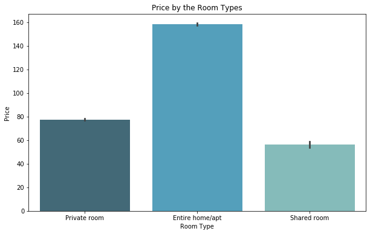

```python
plt.figure(figsize=(10,6))
sns.barplot(x='room_type', y='price', data=price, palette='GnBu_d')
plt.title("Price by the Room Types")
plt.xlabel('Room Type')
plt.ylabel("Price")
plt.show()
```

We can see that the prices of entire home is greater than the other room types which makes sense.

### Locations of the Posts

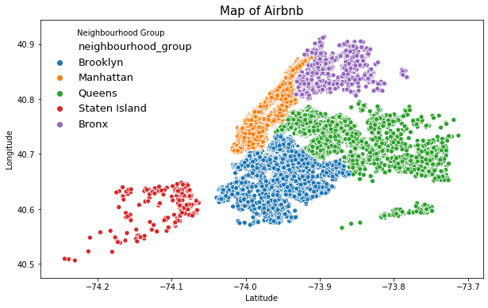

```python
plt.figure(figsize=(10,6))
sns.scatterplot(data=price, x='longitude', y='latitude', hue='neighbourhood_group')
plt.title('Map of Airbnb', fontsize=15)
plt.xlabel('Latitude')
plt.ylabel("Longitude")
plt.legend(title="Neighbourhood Group", frameon=False, fontsize=13)
plt.show()
```

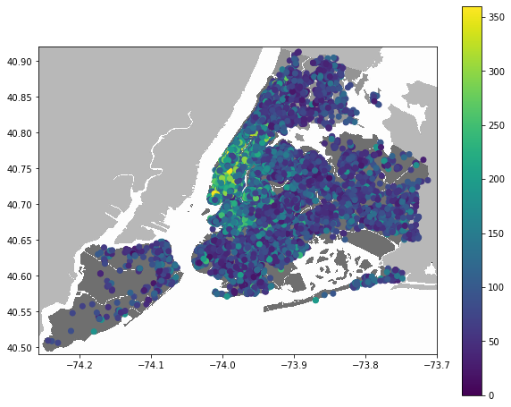

```python
plt.figure(figsize=(10,8))

nyc_img=img.imread('https://github.com/oguzayy/python/blob/master/New_York_City.PNG?raw=true')
plt.imshow(nyc_img, extent=[-74.258, -73.7, 40.49, 40.92])

plt.scatter(data=price, x='longitude', y='latitude', c='price')
plt.colorbar()
plt.show()
```

We can see that the prices in Manhattan (which is shown as orange in the first map) is higher than the other neighbourhoods.